# Stepwise Regression Analysis of MPG in the mtcars Dataset

Data Analysis Report

2025-05-12

## Executive Summary

This report presents the results of a stepwise regression analysis conducted to identify the most influential predictors of Miles Per Gallon (MPG) in the mtcars dataset. The analysis compares a full model (including all predictors) with a stepwise-selected model to determine the optimal combination of variables for predicting MPG.

## Key Findings

### Most Influential Predictors

The stepwise regression identified the following significant predictors of MPG:

```
##           Estimate Std. Error   t value     Pr(>|t|)
## wt       -3.916504  0.7112016 -5.506882 6.952711e-06
## qsec      1.225886  0.2886696  4.246676 2.161737e-04
## amManual  2.935837  1.4109045  2.080819 4.671551e-02
```

### Model Performance Comparison

Model Performance Metrics

| Model | AIC | BIC | R_squared | Adj_R_squared |
| --- | --- | --- | --- | --- |
| Full Model | 163.710 | 181.299 | 0.869 | 0.807 |
| Stepwise Model | 154.119 | 161.448 | 0.850 | 0.834 |

### Best Performing Model

The stepwise model outperforms the full model in several key aspects:

### Model Formula

The final stepwise model is:

```
## mpg ~ wt + qsec + am
```

## Statistical Significance

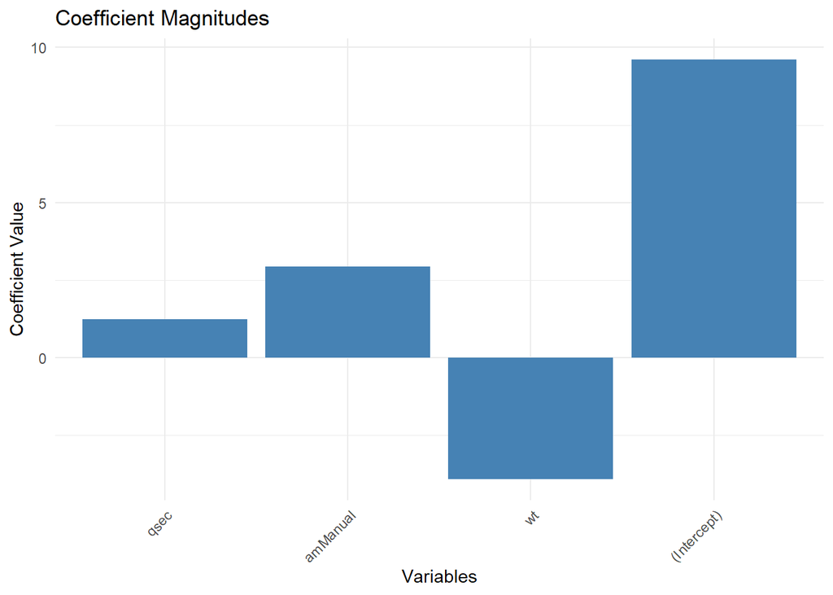

## Model Diagnostics

### Residual Analysis

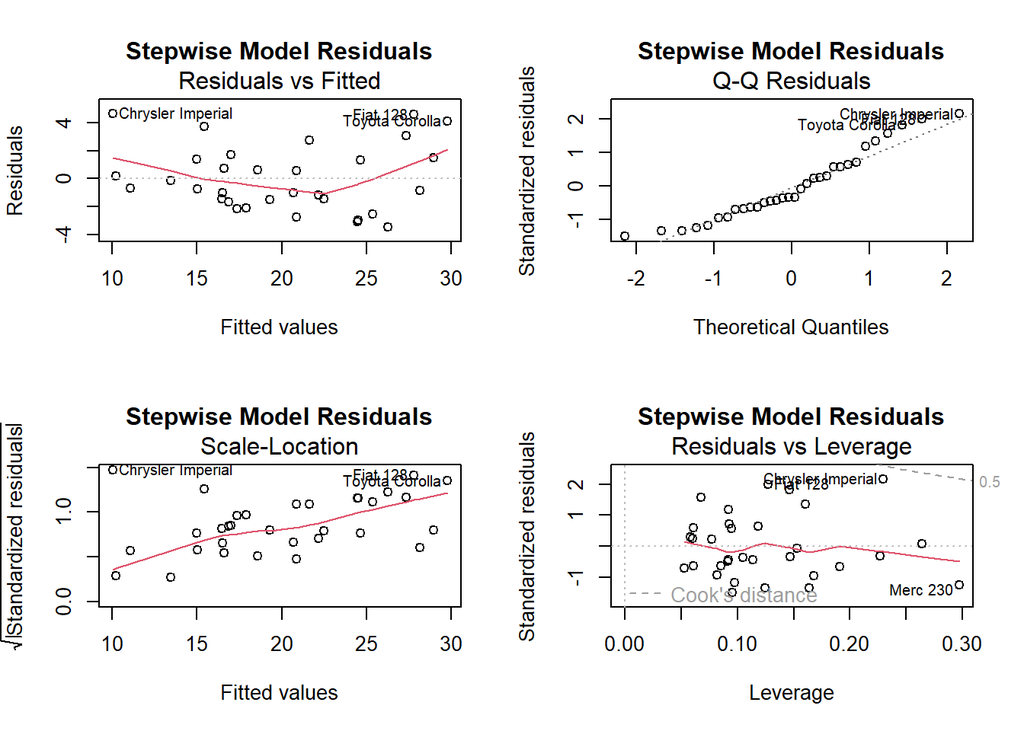

### Multicollinearity Check

Variance Inflation Factors

|  | Variable | VIF |
| --- | --- | --- |
| wt | wt | 2.48 |
| qsec | qsec | 1.36 |
| am | am | 2.54 |

## Conclusion

The stepwise regression analysis successfully identified the most important predictors of MPG while maintaining model parsimony. The selected model provides a good balance between predictive power and model complexity, as evidenced by the improved AIC and BIC values compared to the full model.